# Análise exploratória sobre variantes

Elias, Lucas e Ornella

2022-07-02

# Tratamento dos dados

De início iremos importar a base de dados e criar a variável de `variante`. A criação dessa variável se dá sabendo que as variantes gama, delta e omicron tiveram seus inícios em 01/02/2021, 01-08-2021 e 01-01-2022, respectivamente.

# Informações resumo das variáveis principais

```
## text graphs are displayed; set 'tmp.img.dir' parameter to activate png graphs
```

```
## ### Data Frame Summary
## #### dados
## **Dimensions:** 22049 x 9
## **Duplicates:** 17139
##
## +-----------------+--------------------+--------------------+-----------------------+---------+
## | Variable        | Stats / Values     | Freqs (% of Valid) | Graph                 | Missing |
## +=================+====================+====================+=======================+=========+
## | variante\       | 1\. original\      | 7626 (34.6%)\      | IIIIII \              | 0\      |
## | [factor]        | 2\. gama\          | 10145 (46.0%)\     | IIIIIIIII \           | (0.0%)  |
## |                 | 3\. delta\         | 1597 ( 7.2%)\      | I \                   |         |
## |                 | 4\. omicron        | 2681 (12.2%)       | II                    |         |
## +-----------------+--------------------+--------------------+-----------------------+---------+
## | faixa_et\       | 1\. <20\           | 1806 ( 8.2%)\      | I \                   | 0\      |
## | [factor]        | 2\. 20-34\         | 14365 (65.2%)\     | IIIIIIIIIIIII \       | (0.0%)  |
## |                 | 3\. >=35           | 5878 (26.7%)       | IIIII                 |         |
## +-----------------+--------------------+--------------------+-----------------------+---------+
## | vacina_cov_sel\ | 1\. não\           | 14062 (63.8%)\     | IIIIIIIIIIII \        | 0\      |
## | [character]     | 2\. nao informado\ | 4877 (22.1%)\      | IIII \                | (0.0%)  |
## |                 | 3\. sim            | 3110 (14.1%)       | II                    |         |
## +-----------------+--------------------+--------------------+-----------------------+---------+
## | raca_sel\       | 1\. amarela\       | 158 ( 0.7%)\       | \                     | 0\      |
## | [character]     | 2\. branca\        | 7999 (36.3%)\      | IIIIIII \             | (0.0%)  |
## |                 | 3\. indigena\      | 167 ( 0.8%)\       | \                     |         |
## |                 | 4\. não informado\ | 3083 (14.0%)\      | II \                  |         |
## |                 | 5\. parda\         | 9548 (43.3%)\      | IIIIIIII \            |         |
## |                 | 6\. preta          | 1094 ( 5.0%)       |                       |         |
## +-----------------+--------------------+--------------------+-----------------------+---------+
## | evolucao\       | 1\. cura\          | 18140 (89.9%)\     | IIIIIIIIIIIIIIIII \   | 1882\   |
## | [character]     | 2\. obito          | 2027 (10.1%)       | II                    | (8.5%)  |
## +-----------------+--------------------+--------------------+-----------------------+---------+
## | escol\          | 1\. sem escol\     | 75 ( 0.8%)\        | \                     | 12447\  |
## | [factor]        | 2\. fund1\         | 827 ( 8.6%)\       | I \                   | (56.5%) |
## |                 | 3\. fund2\         | 1821 (19.0%)\      | III \                 |         |
## |                 | 4\. medio\         | 5121 (53.3%)\      | IIIIIIIIII \          |         |
## |                 | 5\. superior       | 1758 (18.3%)       | III                   |         |
## +-----------------+--------------------+--------------------+-----------------------+---------+
## | suport_ven\     | 1\. não\           | 10018 (51.7%)\     | IIIIIIIIII \          | 2662\   |
## | [factor]        | 2\. não invasivo\  | 6760 (34.9%)\      | IIIIII \              | (12.1%) |
## |                 | 3\. invasivo       | 2609 (13.5%)       | II                    |         |
## +-----------------+--------------------+--------------------+-----------------------+---------+
## | uti\            | 1\. não\           | 14062 (71.4%)\     | IIIIIIIIIIIIII \      | 2366\   |
## | [character]     | 2\. sim            | 5621 (28.6%)       | IIIII                 | (10.7%) |
## +-----------------+--------------------+--------------------+-----------------------+---------+
## | inf_inter\      | 1\. não\           | 17510 (98.4%)\     | IIIIIIIIIIIIIIIIIII \ | 4256\   |
## | [character]     | 2\. sim            | 283 ( 1.6%)        |                       | (19.3%) |
## +-----------------+--------------------+--------------------+-----------------------+---------+
```

# Gráficos de frequência

## Casos para cada uma das variantes

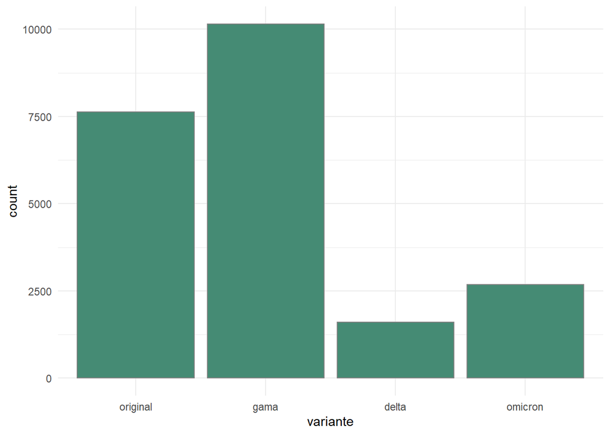

Podemos ver que, para a população de gestantes se puérperas, a variante gama foi a que teve maior número de casos. No tempo podemos tirar algumas informaçõesmais concretas sobre essa questão. Para isso iremos gerar o gráfico a seguir.

## Óbitos para cada uma das variantes

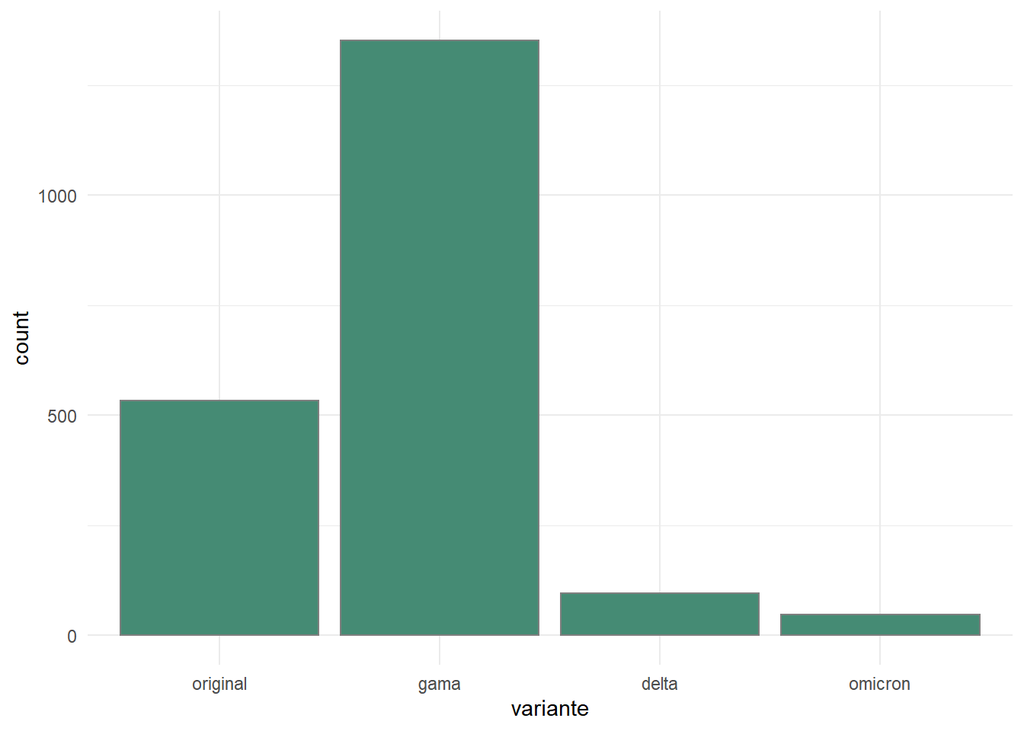

# Evolução no tempo - casos

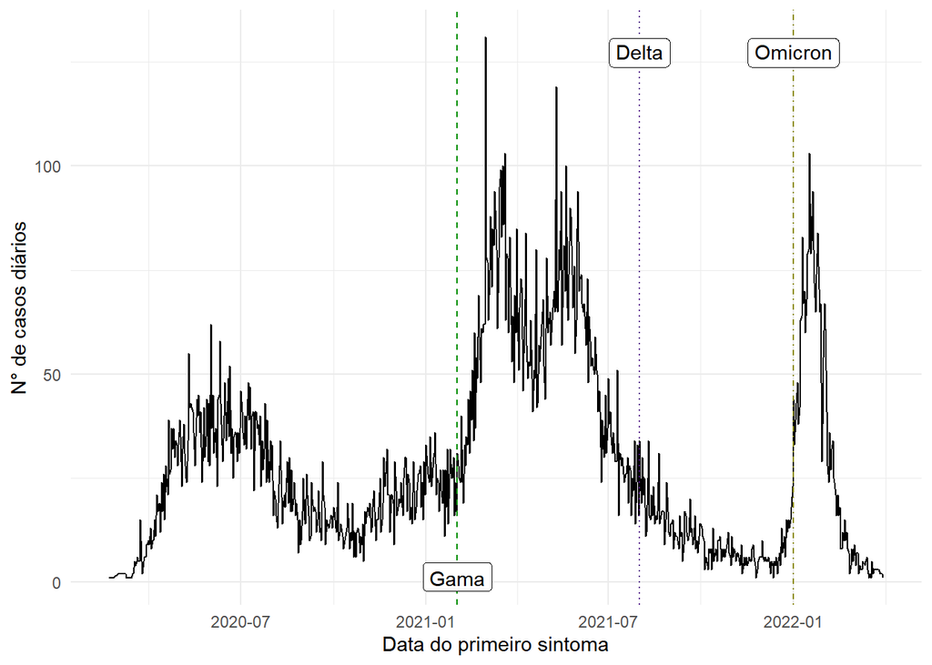

No gráfico acima podemos ver que a variante gama além de ter o maior pico de casos diários, teve uma constância maior em relação ao período de outras variantes como a delta que não teve um contágio alto e a omicron que teve um pico relevante de casos diários mas por um intervalo bem menor. Um dos fatores que podem ter impactado o número de casos que são notificados como SRAG éo início da vacinação. Não temos ao certo uma data em que a vaciação para gestantes e puérperas se iniciou no Brasil a nível nacional, mas temos uma data de referência do início de maio. Sendo assim podemos agregar essa informação ao nosso gráfico anterior, que fica da seguinte forma:

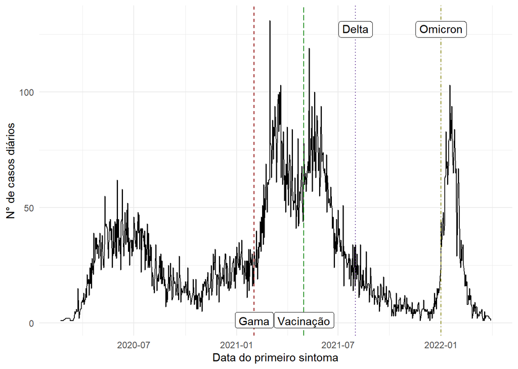

Nesse caso fica claro que após um certo período do início da vacinação tivemos um decrescimento dos casos de SRAG por COVID-19 voltando a ter pico de casos somente com a variante omicron.

## Evolução no tempo - óbitos

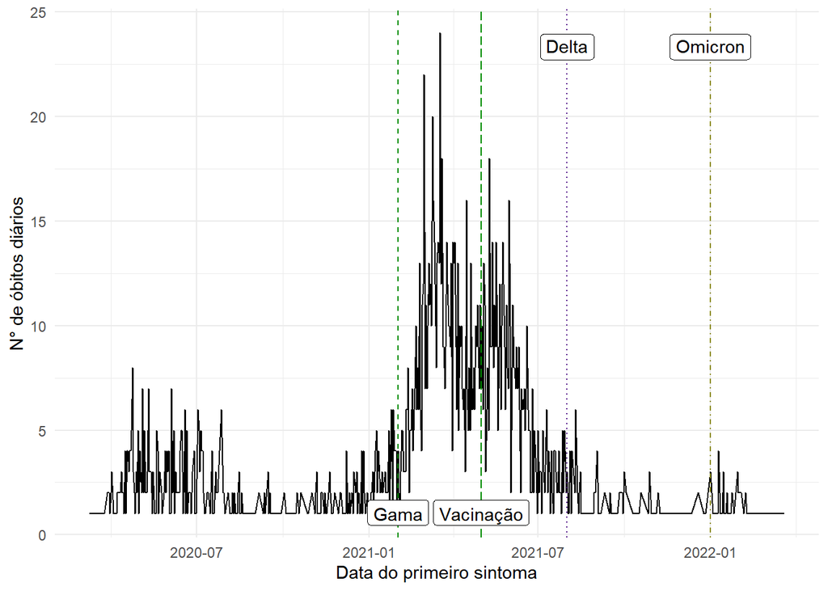

Podemos ver que temos um comportamento que tem uma relação à evolução no tempo de número de casos, sendo a excessão mais clara a variante omicron pois os óbitos não seguem o pico de casos, tendo como possível explicação a maior quantidade de gestantes e puérperas vacinadas.

# Tabela cruzada

Aqui podemos ver as tabelas cruzadas tendo como covariáveis as variantes e como variável resposta a evolução dos casos.

```
##
## ---------- ---------- -------------- -------------- -------------
##              evolucao           cura          obito          <NA>
##   variante
##   original              6513 (85.4%)    533 ( 7.0%)   580 ( 7.6%)
##       gama              7925 (78.1%)   1351 (13.3%)   869 ( 8.6%)
##      delta              1317 (82.5%)     96 ( 6.0%)   184 (11.5%)
##    omicron              2385 (89.0%)     47 ( 1.8%)   249 ( 9.3%)
## ---------- ---------- -------------- -------------- -------------
##
## ----------------------------
##  Chi.squared   df   p.value
## ------------- ---- ---------
##    451.07      3       0
## ----------------------------
```

Pela tabela acima vemos que a variante gama parece ter sido a pior variante para gestantes e puérperas. Vamos fazer algumas análises fixando a variante gama e comparando-a com as demais variantes.

## Gama e Original

```
##
## ---------- ---------- -------------- --------------
##              evolucao           cura          obito
##   variante
##   original              6513 (92.4%)    533 ( 7.6%)
##       gama              7925 (85.4%)   1351 (14.6%)
## ---------- ---------- -------------- --------------
##
## ----------------------------
##  Chi.squared   df   p.value
## ------------- ---- ---------
##   191.4788     1       0
## ----------------------------
##
## ----------------------------------
##  Odds Ratio   Lo - 95%   Hi - 95%
## ------------ ---------- ----------
##     2.08        1.87       2.31
## ----------------------------------
```

## Gama e Delta

```
##
## ---------- ---------- -------------- --------------
##              evolucao           cura          obito
##   variante
##      delta              1317 (93.2%)     96 ( 6.8%)
##       gama              7925 (85.4%)   1351 (14.6%)
## ---------- ---------- -------------- --------------
##
## ----------------------------
##  Chi.squared   df   p.value
## ------------- ---- ---------
##    62.5927     1       0
## ----------------------------
##
## ----------------------------------
##  Odds Ratio   Lo - 95%   Hi - 95%
## ------------ ---------- ----------
##     2.34        1.89       2.90
## ----------------------------------
```

## Gama e Omicron

```
##
## ---------- ---------- -------------- --------------
##              evolucao           cura          obito
##   variante
##    omicron              2385 (98.1%)     47 ( 1.9%)
##       gama              7925 (85.4%)   1351 (14.6%)
## ---------- ---------- -------------- --------------
##
## ----------------------------
##  Chi.squared   df   p.value
## ------------- ---- ---------
##   291.2008     1       0
## ----------------------------
##
## ----------------------------------
##  Odds Ratio   Lo - 95%   Hi - 95%
## ------------ ---------- ----------
##     8.65        6.44      11.61
## ----------------------------------
```

## Conclusão

Vemos que para todos os casos acima temos Odds Ratio (OR) acima de 1 para as variantes quando comparadas a gama, ou seja, temos que no período das variantes original, delta e omicron as gestantes e puérperas tinham 2.08, 2.34 e 8.65 mais chances de se curar, respectivamente, se comparadas com o período da variante gama.